# Características morfométricas nucleares y malignidad de masas mamarias

Trabajo Práctico Integrador — 16.43 Bioestadística (ITBA)

Integrantes: Melanie Natasha Mauas (63517), Agostina Almendros (63096), Thiago Sayegh (62260)

24/11/2026

# 1 Introducción

## 1.1 Problema de interés

El cáncer de mama es la neoplasia más diagnosticada en mujeres: en 2022 se estimaron alrededor de 2,3 millones de casos nuevos y 670.000 muertes en el mundo (Kim et al., 2025). Distinguir a tiempo si una masa mamaria es benigna o maligna permite evitar cirugías innecesarias y, a la vez, no demorar el tratamiento de los tumores malignos.

La **punción aspirativa con aguja fina (PAF)** es un método mínimamente invasivo y de bajo costo para obtener células de la masa. Su principal limitación es que la interpretación citológica es visual y depende del observador. Para objetivarla, Street, Wolberg y Mangasarian (1993) desarrollaron un sistema de análisis de imágenes que digitaliza el preparado, delimita el contorno de cada núcleo celular y calcula diez características morfométricas (tamaño, textura, forma, etc.). La hipótesis subyacente es que los núcleos malignos son más grandes, más heterogéneos y de contorno más irregular.

La selección de estas características responde a su **plausibilidad biológica**: el radio, el perímetro y el área describen dimensiones del tamaño nuclear; la textura representa la variabilidad de la intensidad de gris dentro del núcleo; y las medidas de concavidad describen irregularidades del contorno. Estas dimensiones se relacionan con rasgos morfológicos que pueden observarse en células malignas, como el aumento del tamaño nuclear y la irregularidad de la membrana. Por lo tanto, las variables se consideran por su significado morfológico y no solamente por su disponibilidad en la base de datos. Esta hipótesis se evalúa estadísticamente, sin asumir de antemano que todas las características deban diferir entre diagnósticos.

## 1.2 Dataset y fuente

- **Base:** *Breast Cancer Wisconsin (Diagnostic) Data Set* (WDBC).
- **Origen:** University of Wisconsin Hospitals, Madison (EE. UU.). Autores: W. H. Wolberg, W. N. Street y O. L. Mangasarian. Donada al UCI Machine Learning Repository en noviembre de 1995 (DOI: 10.24432/C5DW2B).
- **Obtenida de:** Kaggle, https://www.kaggle.com/datasets/uciml/breast-cancer-wisconsin-data.
- **Contenido:** 569 masas mamarias (una fila por masa), el diagnóstico (benigno/maligno) y 30 variables cuantitativas: las 10 características nucleares, cada una resumida como media (`_mean`), error estándar (`_se`) y “peor” valor (`_worst`, promedio de los tres núcleos con mayor valor).

## 1.3 Objetivos

**General:** evaluar la asociación entre las características morfométricas nucleares obtenidas por PAF y el diagnóstico de malignidad de masas mamarias.

**Específicos:**

1. Describir y comparar las características nucleares entre masas benignas y malignas (análisis univariado).
2. Construir un modelo de regresión logística multivariado que identifique las características asociadas de forma independiente con la malignidad.
3. Identificar posibles variables confusoras y modificadoras de efecto.
4. Estimar la capacidad discriminativa del modelo (sensibilidad, especificidad, AUC).

## 1.4 Pregunta de investigación (PICO)

> En mujeres con masas mamarias evaluadas por PAF, ¿las características morfométricas nucleares (tamaño, textura, suavidad y concavidad del contorno) se asocian de forma independiente con el diagnóstico de malignidad, y qué capacidad tienen en conjunto para discriminar tumores malignos de benignos?

| Componente | Definición |
| --- | --- |
| **P** (población) | Masas mamarias de pacientes evaluadas mediante PAF en University of Wisconsin Hospitals. |
| **I** (exposición) | Valores más altos de las características morfométricas de los núcleos celulares (radio, textura, suavidad, puntos cóncavos, etc.). |
| **C** (comparación) | Valores más bajos de esas mismas características. |
| **O** (outcome) | Diagnóstico de la masa: maligno (1) vs. benigno (0). |

# 2 Materiales y métodos

## 2.1 Diseño del estudio

Estudio **observacional, analítico, de corte transversal y retrospectivo**, basado en datos secundarios. La exposición (características nucleares) y el outcome (diagnóstico) se registran para cada masa en un mismo momento, sin seguimiento ni intervención del investigador. Por su objetivo de evaluar la capacidad de un conjunto de variables para clasificar un diagnóstico, se trata además de un **estudio de exactitud diagnóstica**, por lo que se toman como referencia las guías **STARD** (además de STROBE para estudios observacionales).

## 2.2 Marco temporal

Los casos provienen de la práctica clínica de University of Wisconsin Hospitals a comienzos de la década de 1990: el sistema de análisis se describió en 1993–1994 y la base se donó al repositorio UCI en noviembre de 1995. La fuente no informa las fechas exactas de inclusión de cada caso, lo que se considera una limitación.

## 2.3 Participantes

**Criterios de inclusión:** masas mamarias con PAF cuyo preparado fue digitalizado y procesado por el sistema de análisis de imágenes, con diagnóstico final (benigno o maligno) registrado.

**Criterios de exclusión:** registros duplicados, con datos faltantes en las variables de interés o con imágenes que no pudieran procesarse.

```r
# 1. Cargar la base
datos_raw <- read.csv("datos/data.csv")

# 2. Limpieza
# La columna "X" aparece vacía porque el CSV de Kaggle tiene una coma final en cada fila.
datos <- datos_raw %>%
  select(-X) %>%
  mutate(diagnosis_num = ifelse(diagnosis == "M", 1, 0),
         diagnostico   = factor(diagnosis, levels = c("B", "M"),
                                labels = c("Benigno", "Maligno")))

c(filas = nrow(datos),
  duplicados = sum(duplicated(datos$id)),
  datos_faltantes = sum(is.na(datos)))
```

```
##           filas      duplicados datos_faltantes
##             569               0               0
```

```r
table(datos$diagnostico)
```

```
##
## Benigno Maligno
##     357     212
```

```r
round(prop.table(table(datos$diagnostico)) * 100, 1)
```

```
##
## Benigno Maligno
##    62.7    37.3
```

No hubo registros duplicados ni datos faltantes, por lo que se incluyeron las **569 masas**: 357 benignas (62,7 %) y 212 malignas (37,3 %).

## 2.4 Variables

**Variable respuesta (Y):** `diagnosis`, cualitativa nominal dicotómica (M = maligno = 1; B = benigno = 0). Sigue una distribución de **Bernoulli** con probabilidad *p* = P(maligno).

**Variables explicativas (X):** las 10 características nucleares en su versión media (`_mean`). Todas son **cuantitativas continuas**, calculadas automáticamente por el software a partir de la imagen digitalizada: el operador marca aproximadamente cada núcleo y un algoritmo de contornos activos (*snakes*) ajusta el borde exacto.

| Variable | Característica | Cómo se mide |
| --- | --- | --- |
| radius_mean | Radio | Distancia media del centro a los puntos del contorno |
| texture_mean | Textura | Desvío estándar de la escala de grises dentro del núcleo |
| perimeter_mean | Perímetro | Longitud del contorno nuclear |
| area_mean | Área | Área encerrada por el contorno |
| smoothness_mean | Suavidad | Variación local de las longitudes de los radios |
| compactness_mean | Compacidad | Perímetro² / área − 1 |
| concavity_mean | Concavidad | Severidad de las porciones cóncavas del contorno |
| concave.points_mean | Puntos cóncavos | Número de porciones cóncavas del contorno |
| symmetry_mean | Simetría | Simetría del núcleo respecto de su eje mayor |
| fractal_dimension_mean | Dimensión fractal | Aproximación de la “línea de costa” − 1 |

Se excluyeron del análisis las versiones `_se` (miden la variabilidad de la estimación, no una característica morfológica adicional del tumor) y `_worst` (resumen los valores más altos de cada característica y presentan elevada redundancia con las medias). Incluir las tres versiones de cada característica habría aumentado considerablemente la cantidad de predictores con información superpuesta, con el riesgo de incrementar la multicolinealidad y la inestabilidad del modelo. Esta decisión define un conjunto inicial de diez predictores con interpretación morfológica directa; no implica que las medidas excluidas carezcan de utilidad en cualquier otro objetivo analítico.

**Variable derivada:** a partir del análisis de supuestos (sección 3.3.3) la textura se categorizó en **terciles** (baja, media, alta), que se incluyen en el modelo mediante dos variables *dummy* con “baja” como categoría de referencia.

## 2.5 Posibles sesgos y cómo se abordan

| Sesgo | Descripción | Abordaje |
| --- | --- | --- |
| **Selección / espectro** | Casos de un único centro de referencia, no de una muestra poblacional; los tumores pueden ser más avanzados o más “típicos” que en la práctica general (Ransohoff y Feinstein, 1978). | No es corregible con los datos; se acota la validez externa a poblaciones similares y se lo explicita como limitación. |
| **Verificación** | Si no todas las masas benignas tuvieron confirmación histológica (por ejemplo, confirmación por seguimiento), el estándar de referencia no es homogéneo. | La base no informa el método de confirmación por caso; se reconoce como limitación. |
| **Información / medición** | El operador marca inicialmente cada núcleo y elige qué zona del preparado digitalizar; esto introduce variabilidad. | Las medidas son calculadas por software, lo que reduce la subjetividad respecto de la lectura visual. |
| **Confusión** | Las características nucleares están fuertemente correlacionadas entre sí; la asociación cruda de una puede deberse a otra. | Análisis multivariado y evaluación del cambio en los coeficientes (log-odds) crudos vs. ajustados (criterio heurístico del 10 %). |
| **Sobreajuste / optimismo** | Evaluar el modelo con los mismos datos con que se ajustó sobreestima su rendimiento. | Modelo parsimonioso y validación cruzada de 10 particiones repetida, incluyendo una variante que repite la selección de variables dentro de cada partición. |

## 2.6 Cálculo del tamaño muestral y poder de la muestra

```r
n_B <- sum(datos$diagnosis_num == 0)
n_M <- sum(datos$diagnosis_num == 1)
prev <- n_M / nrow(datos)

# (a) Comparación univariada de dos grupos: efecto moderado (d de Cohen = 0,5),
#     alfa = 0,05 bilateral, potencia = 0,80
n_t <- pwr.t.test(d = 0.5, sig.level = 0.05, power = 0.80, type = "two.sample")$n
# Corrección conservadora para Mann-Whitney: 0,864 es la cota mínima de su eficiencia
# relativa asintótica frente al test t (bajo normalidad sería 3/pi = 0,955)
n_mw <- n_t / 0.864

# (b) Regresión logística: regla de 10 eventos por variable (Peduzzi et al., 1996)
k_sat <- 10
n_logit <- 10 * k_sat / prev

# (c) Poder de la muestra disponible
pot_d03 <- pwr.t2n.test(n1 = n_B, n2 = n_M, d = 0.3, sig.level = 0.05)$power
pot_d05 <- pwr.t2n.test(n1 = n_B, n2 = n_M, d = 0.5, sig.level = 0.05)$power
d_min   <- pwr.t2n.test(n1 = n_B, n2 = n_M, power = 0.80, sig.level = 0.05)$d

data.frame(
  Criterio = c("Comparación de 2 grupos (t, d = 0,5)",
               "Ídem, ajustado para Mann-Whitney",
               "Regresión logística, 10 EPV con 10 variables"),
  `n ideal` = c(paste(ceiling(n_t), "por grupo"),
                paste(ceiling(n_mw), "por grupo"),
                paste(ceiling(n_logit), "en total")),
  check.names = FALSE) %>% kable(row.names = FALSE)
```

| Criterio | n ideal |
| --- | --- |
| Comparación de 2 grupos (t, d = 0,5) | 64 por grupo |
| Ídem, ajustado para Mann-Whitney | 74 por grupo |
| Regresión logística, 10 EPV con 10 variables | 269 en total |

- **Tamaño ideal.** Para detectar una diferencia moderada (d = 0,5) entre grupos con α = 0,05 y potencia del 80 % se necesitan 74 masas por grupo con Mann-Whitney. Para el modelo logístico saturado con 10 variables, la regla de 10 eventos por variable (EPV) exige al menos 269 masas, dada una prevalencia de malignidad del 37,3 %.
- **Muestra disponible.** Con 357 benignas y 212 malignas se superan ambos requisitos. El poder para detectar un efecto pequeño-moderado (d = 0,3) es de 93,2 %, y el de un efecto moderado (d = 0,5), superior al 99,9 %. El menor efecto detectable con 80 % de potencia es d = 0,24.
- **EPV observados.** Con 212 eventos, el modelo saturado tiene 21,2 EPV y el modelo final (5 coeficientes), 42,4 EPV, muy por encima de 10.

Estos cálculos deben interpretarse como referencias de suficiencia muestral y no como una garantía de ausencia de sobreajuste. La regla de 10 eventos por parámetro es orientativa y no contempla por sí sola la separación, la distribución de los predictores, la complejidad de las transformaciones ni el proceso de selección del modelo. Además, como se utiliza una base ya recolectada, el cálculo evalúa la adecuación de la muestra disponible y no define un reclutamiento prospectivo.

## 2.7 Métodos estadísticos

1. **Descriptivo:** mediana y rango intercuartílico (RIC) por grupo diagnóstico, y coeficiente de asimetría. Se priorizan medidas robustas porque varias características presentan distribuciones asimétricas y valores extremos.
2. **Normalidad:** test de Shapiro-Wilk en cada grupo. Homogeneidad de varianzas: test de Levene. Estos análisis se utilizan junto con histogramas y boxplots para caracterizar la distribución; no se interpretan como una decisión automática aislada.
3. **Comparación univariada:** si ambos grupos son aproximadamente normales, test *t* de Welch; si no, **test U de Mann-Whitney**. Welch se elige porque compara medias de dos grupos independientes y no requiere asumir igualdad de varianzas. Mann-Whitney permite comparar las distribuciones/rangos sin exigir normalidad; no se interpreta necesariamente como un test de medianas salvo que las formas de las distribuciones sean similares. Usar Shapiro-Wilk como criterio de elección es la **estrategia operativa adoptada en este trabajo, no una regla universal**: con muestras de este tamaño (357 y 212) Shapiro-Wilk detecta desvíos mínimos de la normalidad, y el test de Welch es robusto ante desviaciones moderadas gracias al teorema central del límite, por lo que también habría sido una opción válida. Cada test se acompaña del tamaño de efecto que le corresponde: la **correlación biserial por rangos** (*r*<sub>rb</sub> = 2U/(n<sub>M</sub>·n<sub>B</sub>) − 1) para Mann-Whitney y la *d* de Cohen (diferencia de medias estandarizada) para Welch; se informan ambas para todas las variables, la segunda además porque es la escala en la que se calculó el poder. En R, el estadístico W que devuelve `wilcox.test()` ya es la U de Mann-Whitney del primer grupo (cantidad de pares en los que la masa maligna supera a la benigna), no la suma de rangos, por lo que se usa directamente. Los p-valores se corrigen por comparaciones múltiples con el método de Holm para limitar falsos positivos al realizar diez contrastes. Para la textura en terciles se usa el test χ² de independencia, dado que ambas variables son categóricas. Se estiman además los OR crudos por regresión logística simple.
4. **Colinealidad:** matriz de correlación de Spearman y factor de inflación de la varianza (VIF; se considera problemático un VIF > 5). Spearman se utiliza por la posible asimetría y porque interesa detectar asociaciones monotónicas entre predictores.
5. **Multivariado:** regresión logística binaria, porque el diagnóstico es dicotómico. Las variables continuas se estandarizan (media 0, DE 1), de modo que cada OR expresa el cambio en los odds de malignidad por cada aumento de 1 desvío estándar. Se parte de un **modelo inicial completo con las 10 variables candidatas** (denominado en el informe modelo teórico saturado) y se reduce considerando la redundancia biológica/estadística, la colinealidad y la comparación de modelos anidados mediante el test de razón de verosimilitud (LRT) y el AIC. En sentido estadístico estricto, “modelo saturado” tiene otra definición; aquí se usa para referirse al modelo inicial que incluye todos los predictores candidatos.
6. **Supuestos del modelo:** independencia de las observaciones (una masa por fila), ausencia de multicolinealidad (VIF), linealidad entre cada predictor continuo y el logit (test de Box-Tidwell) y evaluación de observaciones influyentes (distancia de Cook). La normalidad de los predictores no es un supuesto de la regresión logística.
7. **Confusión y modificación de efecto:** se explora confusión comparando los coeficientes ajustados (β, en escala log-odds) con los obtenidos al excluir una variable por vez; un cambio relativo mayor al 10 % se toma como señal orientativa: es un criterio heurístico, no un test estadístico. El cambio se mide sobre β y no sobre el OR porque el OR es una transformación exponencial y, con OR grandes como los de este trabajo, el mismo cambio en β se traduce en porcentajes mucho mayores. La modificación de efecto se evalúa agregando interacciones con plausibilidad biológica y comparándolas con el modelo sin interacción mediante LRT.
8. **Bondad de ajuste y desempeño:** test de Hosmer-Lemeshow, curva de calibración, matriz de confusión con punto de corte 0,5 (sensibilidad, especificidad, VPP, VPN) y AUC-ROC. El test de Hosmer-Lemeshow se implementa a mano y se verifica contra `ResourceSelection::hoslem.test`; un resultado no significativo indica que no se detecta falta de ajuste, no que la calibración sea perfecta. El rendimiento se valida internamente por validación cruzada de 10 particiones repetida 10 veces, de dos maneras: (a) reajustando en cada partición el modelo final ya elegido y (b) repitiendo dentro de cada partición todo el proceso de selección de variables (descarte por VIF > 5 y eliminación hacia atrás por LRT), porque la selección hecha con todos los datos hace que (a) no sea una evaluación completamente independiente. El punto de corte 0,5 se utiliza como referencia descriptiva y no se asume que sea necesariamente el umbral clínico óptimo.

Nivel de significación: α = 0,05. Software: R version 4.6.2 (2026-10-29 ucrt).

# 3 Resultados

Las decisiones analíticas se interpretan en función de la pregunta de investigación: primero se describe cómo difieren las características morfométricas entre diagnósticos; luego se evalúa cuáles mantienen una asociación ajustada; finalmente se estudia si el conjunto de variables permite discriminar entre masas benignas y malignas. Esta secuencia evita confundir una diferencia univariada con un efecto independiente o con capacidad predictiva.

## 3.1 Descripción de las variables

```r
asimetria <- function(x) mean((x - mean(x))^3) / sd(x)^3

desc <- lapply(vars, function(v) {
  x <- datos[[v]]
  xb <- x[datos$diagnostico == "Benigno"]; xm <- x[datos$diagnostico == "Maligno"]
  med_ric <- function(z) paste0(fn(median(z), 3), " (", fn(quantile(z, .25), 3), "–", fn(quantile(z, .75), 3), ")")
  data.frame(Variable = etiq[v],
             `Benigno, mediana (RIC)` = med_ric(xb),
             `Maligno, mediana (RIC)` = med_ric(xm),
             `Asimetría` = fn(asimetria(x)),
             `Shapiro p (B)` = fp(shapiro.test(xb)$p.value),
             `Shapiro p (M)` = fp(shapiro.test(xm)$p.value),
             `Levene p` = fp(leveneTest(x ~ datos$diagnostico)$`Pr(>F)`[1]),
             check.names = FALSE)
})
desc <- do.call(rbind, desc); rownames(desc) <- NULL
kable(desc, align = "lcccccc")
```

| Variable | Benigno, mediana (RIC) | Maligno, mediana (RIC) | Asimetría | Shapiro p (B) | Shapiro p (M) | Levene p |
| --- | --- | --- | --- | --- | --- | --- |
| Radio | 12,200 (11,080–13,370) | 17,325 (15,075–19,590) | 0,94 | 0,668 | 0,002 | < 0,001 |
| Textura | 17,390 (15,150–19,760) | 21,460 (19,328–23,765) | 0,65 | < 0,001 | < 0,001 | 0,409 |
| Perímetro | 78,180 (70,870–86,100) | 114,200 (98,745–129,925) | 0,99 | 0,779 | < 0,001 | < 0,001 |
| Área | 458,400 (378,200–551,100) | 932,000 (705,300–1.203,750) | 1,64 | 0,023 | < 0,001 | < 0,001 |
| Suavidad | 0,091 (0,083–0,101) | 0,102 (0,094–0,111) | 0,45 | < 0,001 | 0,021 | 0,360 |
| Compacidad | 0,075 (0,056–0,098) | 0,132 (0,110–0,172) | 1,18 | < 0,001 | < 0,001 | < 0,001 |
| Concavidad | 0,037 (0,020–0,060) | 0,151 (0,110–0,203) | 1,39 | < 0,001 | < 0,001 | < 0,001 |
| Puntos cóncavos | 0,023 (0,015–0,033) | 0,086 (0,065–0,103) | 1,17 | < 0,001 | < 0,001 | < 0,001 |
| Simetría | 0,171 (0,158–0,189) | 0,190 (0,174–0,210) | 0,72 | < 0,001 | < 0,001 | 0,154 |
| Dimensión fractal | 0,062 (0,059–0,066) | 0,062 (0,057–0,067) | 1,30 | < 0,001 | < 0,001 | 0,014 |

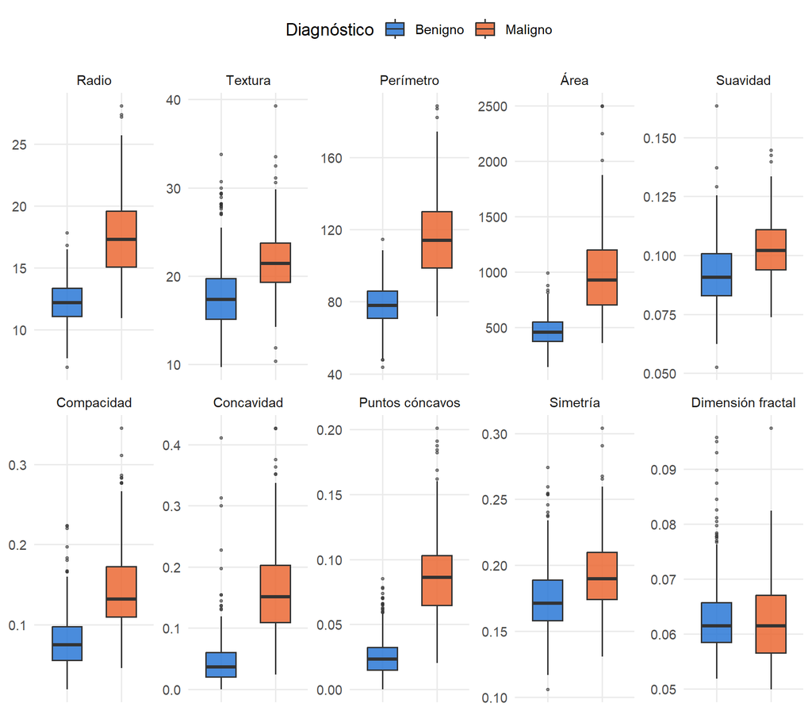

Figura 1. Distribución de las características nucleares según el diagnóstico.

```r
datos %>%
  select(diagnostico, all_of(vars)) %>%
  pivot_longer(-diagnostico, names_to = "variable", values_to = "valor") %>%
  mutate(variable = factor(etiq[variable], levels = etiq)) %>%
  ggplot(aes(diagnostico, valor, fill = diagnostico)) +
  geom_boxplot(width = 0.55, outlier.size = 0.8, outlier.alpha = 0.5, alpha = 0.85) +
  facet_wrap(~ variable, scales = "free_y", ncol = 5) +
  scale_fill_manual(values = col_dx) +
  labs(x = NULL, y = NULL, fill = "Diagnóstico") +
  theme(axis.text.x = element_blank())
```

Ninguna variable es normal en ambos grupos (Shapiro-Wilk p < 0,05 en casi todos los casos) y la mayoría presenta **asimetría positiva** (cola a derecha), algo esperable en medidas de tamaño y forma que son estrictamente positivas. En la mayoría de las variables las varianzas también difieren entre grupos (Levene). Por eso, según la estrategia definida en métodos, las comparaciones se hacen con el **test de Mann-Whitney**, que no requiere normalidad. Con estos tamaños de grupo el test de Welch también habría sido defendible; dado el tamaño de los efectos observados, la elección no cambia las conclusiones. La respuesta es dicotómica (Bernoulli), por lo que el modelo multivariado adecuado es la **regresión logística**.

## 3.2 Análisis univariado

```r
sd_dat <- sapply(vars, function(v) sd(datos[[v]]))

uni <- lapply(vars, function(v) {
  x <- datos[[v]]
  xb <- x[datos$diagnosis_num == 0]; xm <- x[datos$diagnosis_num == 1]
  normal <- shapiro.test(xb)$p.value > 0.05 & shapiro.test(xm)$p.value > 0.05
  if (normal) {
    test <- "t de Welch"; p <- t.test(xm, xb)$p.value
  } else {
    test <- "Mann-Whitney"; p <- wilcox.test(xm, xb, exact = FALSE)$p.value
  }
  # En R, el estadístico W de wilcox.test(x, y) ya es la U de Mann-Whitney de x:
  # W = (suma de rangos de x) - n_x (n_x + 1) / 2 = n.º de pares con x > y. No hay que convertirlo.
  U <- wilcox.test(xm, xb, exact = FALSE)$statistic
  r_rb <- 2 * U / (length(xm) * length(xb)) - 1          # tamaño de efecto de Mann-Whitney
  # d de Cohen (DE combinada): tamaño de efecto para diferencia de medias (t / Welch)
  de_comb <- sqrt(((length(xm) - 1) * var(xm) + (length(xb) - 1) * var(xb)) / (length(x) - 2))
  d_cohen <- (mean(xm) - mean(xb)) / de_comb
  z <- (x - mean(x)) / sd(x)
  m <- glm(datos$diagnosis_num ~ z, family = binomial)
  or <- exp(c(coef(m)[2], confint.default(m)[2, ]))
  data.frame(var = v, Variable = etiq[v], Test = test, p = p, r_rb = r_rb, d = d_cohen,
             OR = or[1], LI = or[2], LS = or[3])
})
uni <- do.call(rbind, uni)
uni$p_holm <- p.adjust(uni$p, method = "holm")

uni %>%
  transmute(Variable, Test, `p` = fp(p), `p (Holm)` = fp(p_holm),
            `r rb` = fn(r_rb), `d de Cohen` = fn(d),
            `OR crudo por 1 DE (IC 95 %)` = paste0(fn(OR), " (", fn(LI), "–", fn(LS), ")")) %>%
  kable(row.names = FALSE, align = "llccccc")
```

| Variable | Test | p | p (Holm) | r rb | d de Cohen | OR crudo por 1 DE (IC 95 %) |
| --- | --- | --- | --- | --- | --- | --- |
| Radio | Mann-Whitney | < 0,001 | < 0,001 | 0,88 | 2,21 | 38,18 (20,07–72,64) |
| Textura | Mann-Whitney | < 0,001 | < 0,001 | 0,55 | 0,94 | 2,74 (2,20–3,42) |
| Perímetro | Mann-Whitney | < 0,001 | < 0,001 | 0,89 | 2,29 | 53,77 (26,50–109,08) |
| Área | Mann-Whitney | < 0,001 | < 0,001 | 0,88 | 2,08 | 62,88 (29,66–133,34) |
| Suavidad | Mann-Whitney | < 0,001 | < 0,001 | 0,44 | 0,79 | 2,33 (1,89–2,87) |
| Compacidad | Mann-Whitney | < 0,001 | < 0,001 | 0,73 | 1,53 | 6,83 (4,91–9,50) |
| Concavidad | Mann-Whitney | < 0,001 | < 0,001 | 0,88 | 2,00 | 18,87 (11,75–30,29) |
| Puntos cóncavos | Mann-Whitney | < 0,001 | < 0,001 | 0,93 | 2,55 | 63,54 (31,76–127,13) |
| Simetría | Mann-Whitney | < 0,001 | < 0,001 | 0,40 | 0,72 | 2,13 (1,74–2,61) |
| Dimensión fractal | Mann-Whitney | 0,537 | 0,537 | -0,03 | -0,03 | 0,97 (0,82–1,16) |

Tras corregir por comparaciones múltiples, **9 de las 10 características difieren significativamente** entre masas benignas y malignas. Solo la dimensión fractal no muestra diferencias. Los efectos más grandes corresponden a las medidas de **tamaño** (radio, perímetro, área) y de **concavidad del contorno** (puntos cóncavos, concavidad), con *r*<sub>rb</sub> cercanos a 0,9: en esas variables, una masa maligna tiene un valor mayor que una benigna en la gran mayoría de los pares comparados. En escala de diferencia de medias, esas mismas variables tienen *d* de Cohen de 2 o más, muy por encima del umbral convencional de efecto grande (0,8). La textura y la suavidad muestran efectos moderados en *r*<sub>rb</sub> (*d* entre 0,79 y 0,94). Como todas las comparaciones se resolvieron con Mann-Whitney, el tamaño de efecto que acompaña al test es *r*<sub>rb</sub>; la *d* de Cohen se informa como medida complementaria.

```r
cortes_tex <- quantile(datos$texture_mean, c(0, 1/3, 2/3, 1))
datos <- datos %>%
  mutate(textura_cat = cut(texture_mean, cortes_tex, include.lowest = TRUE,
                           labels = c("Baja", "Media", "Alta")))

tab_tex <- table(Textura = datos$textura_cat, `Diagnóstico` = datos$diagnostico)
tab_tex
```

```
##        Diagnóstico
## Textura Benigno Maligno
##   Baja      169      21
##   Media     119      71
##   Alta       69     120
```

```r
round(prop.table(tab_tex, 1) * 100, 1)
```

```
##        Diagnóstico
## Textura Benigno Maligno
##   Baja     88.9    11.1
##   Media    62.6    37.4
##   Alta     36.5    63.5
```

```r
chi_tex <- chisq.test(tab_tex)
chi_tex
```

```
##
##  Pearson's Chi-squared test
##
## data:  tab_tex
## X-squared = 111.46, df = 2, p-value < 2.2e-16
```

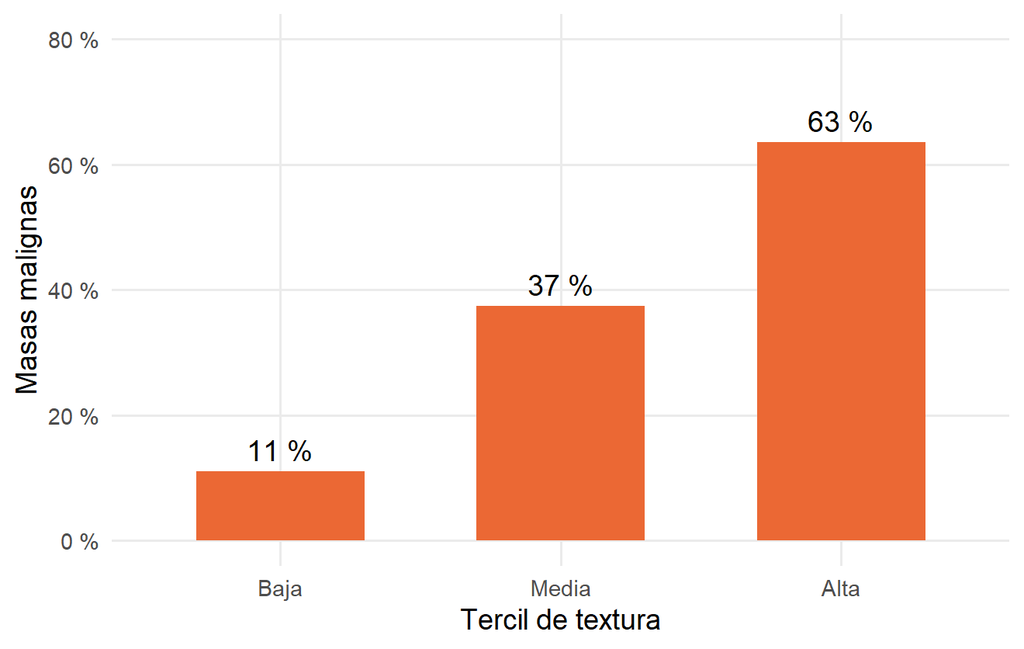

Figura 2. Proporción de masas malignas según el tercil de textura.

```r
datos %>%
  group_by(textura_cat) %>%
  summarise(prop = mean(diagnosis_num), n = n()) %>%
  ggplot(aes(textura_cat, prop)) +
  geom_col(fill = col_dx["Maligno"], width = 0.6) +
  geom_text(aes(label = paste0(fn(100 * prop, 0), " %")), vjust = -0.5) +
  scale_y_continuous(labels = function(x) paste0(x * 100, " %"), limits = c(0, 0.8)) +
  labs(x = "Tercil de textura", y = "Masas malignas")
```

La proporción de malignidad crece con la textura: 11,1 % en el tercil bajo, 37,4 % en el medio y 63,5 % en el alto (χ² = 111,5, gl = 2, p < 0,001).

## 3.3 Análisis multivariado

### 3.3.1 Elección del modelo

Como la variable respuesta es dicotómica, se utiliza **regresión logística binaria**:

$$\text{logit}(p) = \ln\left(\frac{p}{1-p}\right) = \beta_0 + \beta_1 X_1 + \dots + \beta_k X_k$$

donde *p* = P(maligno). El modelo permite estimar el OR de cada característica **ajustado** por las demás y obtener una probabilidad predicha de malignidad para cada masa.

### 3.3.2 Modelo teórico saturado

```r
# Variables estandarizadas: OR por cada aumento de 1 DE
datos_z <- datos %>% mutate(across(all_of(vars), ~ as.numeric(scale(.x))))

f_sat <- as.formula(paste("diagnosis_num ~", paste(vars, collapse = " + ")))
m_sat <- glm(f_sat, data = datos_z, family = binomial)
summary(m_sat)
```

```
##
## Call:
## glm(formula = f_sat, family = binomial, data = datos_z)
##
## Coefficients:
##                        Estimate Std. Error z value Pr(>|z|)
## (Intercept)             0.48702    0.56432   0.863   0.3881
## radius_mean            -7.22185   13.09494  -0.551   0.5813
## texture_mean            1.65476    0.27758   5.961  2.5e-09 ***
## perimeter_mean         -1.73763   12.27499  -0.142   0.8874
## area_mean              14.00485    5.89090   2.377   0.0174 *
## smoothness_mean         1.07495    0.44942   2.392   0.0168 *
## compactness_mean       -0.07723    1.07434  -0.072   0.9427
## concavity_mean          0.67512    0.64733   1.043   0.2970
## concave.points_mean     2.59287    1.10701   2.342   0.0192 *
## symmetry_mean           0.44626    0.29143   1.531   0.1257
## fractal_dimension_mean -0.48248    0.60406  -0.799   0.4244
## ---
## Signif. codes:  0 '***' 0.001 '**' 0.01 '*' 0.05 '.' 0.1 ' ' 1
##
## (Dispersion parameter for binomial family taken to be 1)
##
##     Null deviance: 751.44  on 568  degrees of freedom
## Residual deviance: 146.13  on 558  degrees of freedom
## AIC: 168.13
##
## Number of Fisher Scoring iterations: 9
```

```r
data.frame(Variable = etiq[vars], VIF = fn(vif(m_sat), 1)) %>% kable(row.names = FALSE)
```

| Variable | VIF |
| --- | --- |
| Radio | 899,5 |
| Textura | 1,8 |
| Perímetro | 699,0 |
| Área | 129,6 |
| Suavidad | 4,4 |
| Compacidad | 15,3 |
| Concavidad | 5,3 |
| Puntos cóncavos | 5,9 |
| Simetría | 1,8 |
| Dimensión fractal | 9,8 |

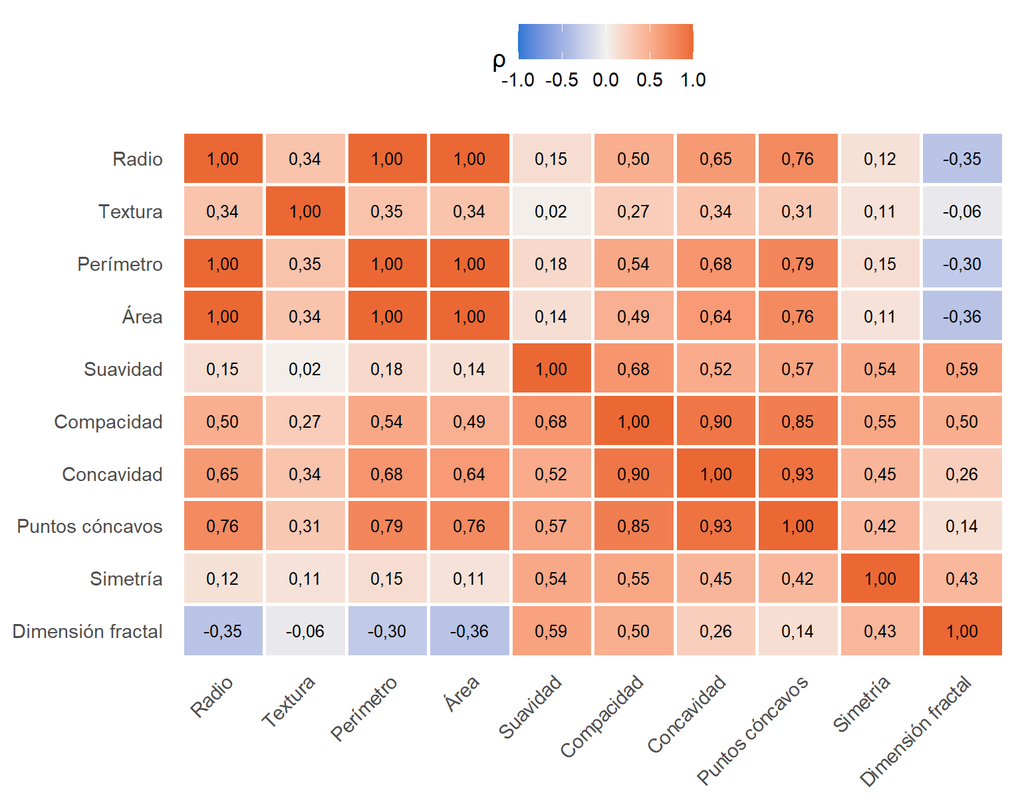

Figura 3. Correlación de Spearman entre las características nucleares.

```r
cor_m <- cor(datos[, vars], method = "spearman")
dimnames(cor_m) <- list(etiq, etiq)
as.data.frame(as.table(cor_m)) %>%
  ggplot(aes(Var1, factor(Var2, levels = rev(etiq)), fill = Freq)) +
  geom_tile(color = "white", linewidth = 0.8) +
  geom_text(aes(label = fn(Freq, 2)), size = 3) +
  scale_fill_gradient2(low = "#2a78d6", mid = "#f2f1ee", high = "#eb6834",
                       midpoint = 0, limits = c(-1, 1), name = "ρ") +
  labs(x = NULL, y = NULL) +
  theme(axis.text.x = element_text(angle = 45, hjust = 1), panel.grid = element_blank())
```

El modelo saturado presenta una **multicolinealidad severa**: el radio, el perímetro y el área tienen VIF de 900, 699 y 130, y se correlacionan entre sí con ρ ≈ 1 porque miden lo mismo: el tamaño del núcleo. Algo similar ocurre con la compacidad, la concavidad y los puntos cóncavos (ρ entre 0,85 y 0,93). Por eso los coeficientes del modelo saturado son inestables, tienen errores estándar enormes e incluso cambian de signo (el radio aparece con OR < 1, contradiciendo el análisis univariado). Este modelo no es interpretable y debe reducirse.

### 3.3.3 Reducción del modelo y supuestos

**Paso 1, eliminar la colinealidad.** De cada grupo de variables redundantes se conserva una representativa:

- **Tamaño:** radio (la medida más directa; perímetro y área derivan de ella).
- **Concavidad del contorno:** puntos cóncavos (el mayor efecto univariado del grupo).

```r
m_int <- glm(diagnosis_num ~ radius_mean + texture_mean + smoothness_mean +
               concave.points_mean + symmetry_mean + fractal_dimension_mean,
             data = datos_z, family = binomial)
data.frame(Variable = etiq[names(vif(m_int))], VIF = fn(vif(m_int), 2)) %>% kable(row.names = FALSE)
```

| Variable | VIF |
| --- | --- |
| Radio | 2,53 |
| Textura | 1,64 |
| Suavidad | 2,58 |
| Puntos cóncavos | 2,69 |
| Simetría | 1,57 |
| Dimensión fractal | 2,65 |

```r
drop1(m_int, test = "LRT")
```

|  | Df | Deviance | AIC | LRT | Pr(>Chi) |
| --- | --- | --- | --- | --- | --- |
|  | NA | 156.6388 | 170.6388 | NA | NA |
| radius_mean | 1 | 175.3407 | 187.3407 | 18.7019668 | 0.0000153 |
| texture_mean | 1 | 207.0270 | 219.0270 | 50.3882455 | 0.0000000 |
| smoothness_mean | 1 | 160.0889 | 172.0889 | 3.4501474 | 0.0632461 |
| concave.points_mean | 1 | 177.7981 | 189.7981 | 21.1592997 | 0.0000042 |
| symmetry_mean | 1 | 159.8972 | 171.8972 | 3.2584517 | 0.0710562 |
| fractal_dimension_mean | 1 | 157.3819 | 169.3819 | 0.7431652 | 0.3886488 |

Al eliminar las variables redundantes todos los VIF quedan por debajo de 5. La simetría y la dimensión fractal no aportan significativamente al modelo (LRT p > 0,05).

**Paso 2, eliminar variables que no aportan.**

```r
m_red <- glm(diagnosis_num ~ radius_mean + texture_mean + smoothness_mean + concave.points_mean,
             data = datos_z, family = binomial)
anova(m_red, m_int, test = "LRT")
```

| Resid. Df | Resid. Dev | Df | Deviance | Pr(>Chi) |
| --- | --- | --- | --- | --- |
| 564 | 160.3203 | NA | NA | NA |
| 562 | 156.6388 | 2 | 3.681517 | 0.158697 |

```r
c(AIC_intermedio = AIC(m_int), AIC_reducido = AIC(m_red))
```

```
## AIC_intermedio   AIC_reducido
##       170.6388       170.3203
```

Excluir la simetría y la dimensión fractal no empeora el ajuste (LRT p = 0,159) y el AIC es similar, por lo que se prefiere el modelo más simple.

**Paso 3, supuesto de linealidad en el logit (Box-Tidwell).** Se agrega a cada predictor continuo, en su escala original, el término *X·ln(X)*; si su coeficiente es significativo, la relación entre esa variable y el logit no es lineal. Como los puntos cóncavos tienen valores iguales a 0, se les suma una constante pequeña (0,01).

```r
bt_dat <- datos %>% mutate(cp = concave.points_mean + 0.01)
m_bt <- glm(diagnosis_num ~ radius_mean + texture_mean + smoothness_mean + cp +
              I(radius_mean * log(radius_mean)) + I(texture_mean * log(texture_mean)) +
              I(smoothness_mean * log(smoothness_mean)) + I(cp * log(cp)),
            data = bt_dat, family = binomial)
bt <- summary(m_bt)$coefficients[6:9, ]
data.frame(Variable = c("Radio", "Textura", "Suavidad", "Puntos cóncavos"),
           `Coef. X·ln(X)` = fn(bt[, 1]), `p` = fp(bt[, 4]), check.names = FALSE) %>%
  kable(row.names = FALSE)
```

| Variable | Coef. X·ln(X) | p |
| --- | --- | --- |
| Radio | 1,66 | 0,324 |
| Textura | -1,90 | < 0,001 |
| Suavidad | -107,06 | 0,638 |
| Puntos cóncavos | 41,46 | 0,522 |

La **textura no cumple el supuesto de linealidad** (p < 0,001); las demás variables sí. La relación de la textura con el logit no es una recta: el coeficiente negativo indica una curva cóncava, en la que el logit sube rápido en los valores bajos y medios y cada vez menos en los valores altos. Por eso la textura se incorpora **categorizada en terciles**, mediante dos variables *dummy*:

| Tercil | Rango de textura | Dummy `Media` | Dummy `Alta` |
| --- | --- | --- | --- |
| Baja (referencia) | 9,71–17,19 | 0 | 0 |
| Media | 17,19–20,74 | 1 | 0 |
| Alta | 20,74–39,28 | 0 | 1 |

R crea las dummies automáticamente al incluir un factor; se muestran explícitamente para verificar la codificación:

```r
head(model.matrix(~ textura_cat, data = datos))
```

```
##   (Intercept) textura_catMedia textura_catAlta
## 1           1                0               0
## 2           1                1               0
## 3           1                0               1
## 4           1                1               0
## 5           1                0               0
## 6           1                0               0
```

```r
m_lin <- glm(diagnosis_num ~ radius_mean + texture_mean + smoothness_mean + concave.points_mean,
             data = datos_z, family = binomial)
m_final <- glm(diagnosis_num ~ radius_mean + textura_cat + smoothness_mean + concave.points_mean,
               data = datos_z, family = binomial)
c(AIC_textura_lineal = AIC(m_lin), AIC_textura_terciles = AIC(m_final))
```

```
##   AIC_textura_lineal AIC_textura_terciles
##             170.3203             168.7017
```

Con la textura en terciles el AIC mejora (168,7 vs. 170,3).

### 3.3.4 Modificación de efecto (interacciones)

Se evalúan las interacciones biológicamente plausibles entre las variables del modelo, comparando cada modelo con interacción contra el modelo sin ella (LRT):

```r
inter <- c("radius_mean:textura_cat", "radius_mean:concave.points_mean",
           "radius_mean:smoothness_mean", "textura_cat:concave.points_mean",
           "textura_cat:smoothness_mean", "smoothness_mean:concave.points_mean")
res_int <- t(sapply(inter, function(it) {
  mi <- update(m_final, as.formula(paste(". ~ . +", it)))
  a <- anova(m_final, mi, test = "LRT")
  c(gl = a$Df[2], LRT = a$Deviance[2], p = a$`Pr(>Chi)`[2])
}))
data.frame(`Interacción` = gsub("_mean|_cat", "", inter),
           gl = res_int[, "gl"], `Chi²` = fn(res_int[, "LRT"]), p = fp(res_int[, "p"]),
           check.names = FALSE) %>% kable(row.names = FALSE)
```

| Interacción | gl | Chi² | p |
| --- | --- | --- | --- |
| radius:textura | 2 | 2,61 | 0,271 |
| radius:concave.points | 1 | 1,77 | 0,183 |
| radius:smoothness | 1 | 1,86 | 0,173 |
| textura:concave.points | 2 | 0,41 | 0,813 |
| textura:smoothness | 2 | 0,24 | 0,887 |
| smoothness:concave.points | 1 | 1,35 | 0,245 |

Ninguna interacción es significativa (todas con p > 0,17), es decir, **no hay evidencia de modificación de efecto**: la asociación de cada característica con la malignidad es similar en todos los niveles de las demás.

### 3.3.5 Confusión

Se compara el coeficiente (β, log-odds) de cada variable en el modelo final con el que resulta al excluir, una por vez, cada una de las demás. Un cambio relativo mayor al 10 % se toma como **señal orientativa** de que la variable excluida actúa como confusora de esa asociación; es un criterio heurístico y no un test estadístico.

```r
or_final <- exp(coef(m_final))
b_final  <- coef(m_final)
preds <- c("radius_mean", "textura_cat", "smoothness_mean", "concave.points_mean")
etiq_p <- c(radius_mean = "Radio", textura_cat = "Textura (terciles)",
            smoothness_mean = "Suavidad", concave.points_mean = "Puntos cóncavos")
coef_lab <- c(radius_mean = "Radio", textura_catMedia = "Textura media",
              textura_catAlta = "Textura alta", smoothness_mean = "Suavidad",
              concave.points_mean = "Puntos cóncavos")

conf <- sapply(preds, function(excl) {
  m_sin <- update(m_final, as.formula(paste(". ~ . -", excl)))
  b_sin <- coef(m_sin)
  comunes <- setdiff(names(coef_lab), names(coef(m_final))[grepl(excl, names(coef(m_final)))])
  out <- setNames(rep(NA, length(coef_lab)), names(coef_lab))
  out[comunes] <- 100 * (b_sin[comunes] - b_final[comunes]) / b_final[comunes]
  out
})
conf_tab <- data.frame(Coeficiente = coef_lab[rownames(conf)], check.names = FALSE)
for (j in preds) conf_tab[[paste("Sin", etiq_p[j])]] <- ifelse(is.na(conf[, j]), "—", paste0(fn(conf[, j], 1), " %"))
kable(conf_tab, row.names = FALSE,
      caption = "Cambio porcentual del coeficiente β (log-odds) al excluir cada variable del modelo final")
```

Cambio porcentual del coeficiente β (log-odds) al excluir cada variable del modelo final

| Coeficiente | Sin Radio | Sin Textura (terciles) | Sin Suavidad | Sin Puntos cóncavos |
| --- | --- | --- | --- | --- |
| Radio | — | -23,1 % | -19,9 % | 64,6 % |
| Textura media | -21,3 % | — | -8,8 % | 4,8 % |
| Textura alta | -12,9 % | — | -6,0 % | 1,5 % |
| Suavidad | -202,1 % | -86,2 % | — | 221,4 % |
| Puntos cóncavos | 63,8 % | 1,0 % | 23,9 % | — |

```r
or_crudo <- sapply(names(coef_lab), function(cf) {
  v <- if (grepl("textura", cf)) "textura_cat" else cf
  m <- glm(as.formula(paste("diagnosis_num ~", v)), data = datos_z, family = binomial)
  exp(coef(m)[cf])
})
b_crudo <- log(or_crudo); b_ajust <- b_final[names(coef_lab)]
data.frame(Variable = coef_lab,
           `β crudo` = fn(b_crudo), `β ajustado` = fn(b_ajust),
           `Cambio en β` = paste0(fn(100 * (b_crudo - b_ajust) / b_ajust, 0), " %"),
           `OR crudo` = fn(or_crudo), `OR ajustado` = fn(or_final[names(coef_lab)]),
           check.names = FALSE) %>% kable(row.names = FALSE)
```

| Variable | β crudo | β ajustado | Cambio en β | OR crudo | OR ajustado |
| --- | --- | --- | --- | --- | --- |
| Radio | 3,64 | 3,02 | 21 % | 38,18 | 20,52 |
| Textura media | 1,57 | 2,36 | -33 % | 4,80 | 10,56 |
| Textura alta | 2,64 | 3,87 | -32 % | 14,00 | 48,17 |
| Suavidad | 0,85 | 0,60 | 42 % | 2,33 | 1,81 |
| Puntos cóncavos | 4,15 | 3,13 | 33 % | 63,54 | 22,83 |

- **El radio y los puntos cóncavos se confunden mutuamente.** Al excluir uno, el coeficiente del otro aumenta alrededor de un 65 %, y sus coeficientes crudos son mayores que los ajustados, porque ambas variables están correlacionadas (ρ ≈ 0,76): los núcleos grandes también tienden a tener contornos más irregulares. En el análisis crudo, parte de la asociación atribuida a una corresponde en realidad a la otra.
- **La suavidad muestra señal de confusión sobre el radio y los puntos cóncavos** aunque su propia asociación sea marginal: al excluirla, sus coeficientes cambian un 20 % y un 24 %, respectivamente. Sobre la textura el cambio es menor al 10 % (9 % y 6 %), por lo que no se la considera confusora de esa asociación. Por su efecto sobre el radio y los puntos cóncavos **se conserva en el modelo** (criterio de selección intencionada de Hosmer y Lemeshow).
- **La textura y el radio** también se modifican mutuamente: sin la textura, el coeficiente del radio cambia un 23 %. En el sentido opuesto al del radio, la textura tiene un coeficiente ajustado mayor que el crudo: el ajuste “desenmascara” parte de su asociación.
- El coeficiente de la suavidad es el más inestable ante cualquier exclusión; como es pequeño y no significativo, sus cambios porcentuales son grandes y no deben sobreinterpretarse.

Estas lecturas son orientativas: el umbral del 10 % es una convención, y en variables que son manifestaciones correlacionadas de un mismo proceso (ver Interpretación) “confusión” describe superposición de información más que un sesgo causal clásico.

### 3.3.6 Modelo final

```r
summary(m_final)
```

```
##
## Call:
## glm(formula = diagnosis_num ~ radius_mean + textura_cat + smoothness_mean +
##     concave.points_mean, family = binomial, data = datos_z)
##
## Coefficients:
##                     Estimate Std. Error z value Pr(>|z|)
## (Intercept)          -2.8427     0.4988  -5.699 1.21e-08 ***
## radius_mean           3.0214     0.6234   4.846 1.26e-06 ***
## textura_catMedia      2.3574     0.6037   3.905 9.41e-05 ***
## textura_catAlta       3.8748     0.6520   5.943 2.80e-09 ***
## smoothness_mean       0.5951     0.3579   1.663   0.0964 .
## concave.points_mean   3.1282     0.6559   4.770 1.85e-06 ***
## ---
## Signif. codes:  0 '***' 0.001 '**' 0.01 '*' 0.05 '.' 0.1 ' ' 1
##
## (Dispersion parameter for binomial family taken to be 1)
##
##     Null deviance: 751.44  on 568  degrees of freedom
## Residual deviance: 156.70  on 563  degrees of freedom
## AIC: 168.7
##
## Number of Fisher Scoring iterations: 8
```

```r
ic <- exp(confint.default(m_final))
tab_final <- data.frame(
  Variable = c("(Intercepto)", coef_lab[names(coef(m_final))[-1]]),
  `β` = fn(coef(m_final), 3),
  `OR (IC 95 %)` = paste0(fn(or_final), " (", fn(ic[, 1]), "–", fn(ic[, 2]), ")"),
  p = fp(summary(m_final)$coefficients[, 4]),
  check.names = FALSE)
kable(tab_final, row.names = FALSE, caption = "Modelo logístico final. Variables continuas estandarizadas (OR por 1 DE).")
```

Modelo logístico final. Variables continuas estandarizadas (OR por 1 DE).

| Variable | β | OR (IC 95 %) | p |
| --- | --- | --- | --- |
| (Intercepto) | -2,843 | 0,06 (0,02–0,15) | < 0,001 |
| Radio | 3,021 | 20,52 (6,05–69,64) | < 0,001 |
| Textura media | 2,357 | 10,56 (3,24–34,49) | < 0,001 |
| Textura alta | 3,875 | 48,17 (13,42–172,90) | < 0,001 |
| Suavidad | 0,595 | 1,81 (0,90–3,66) | 0,096 |
| Puntos cóncavos | 3,128 | 22,83 (6,31–82,57) | < 0,001 |

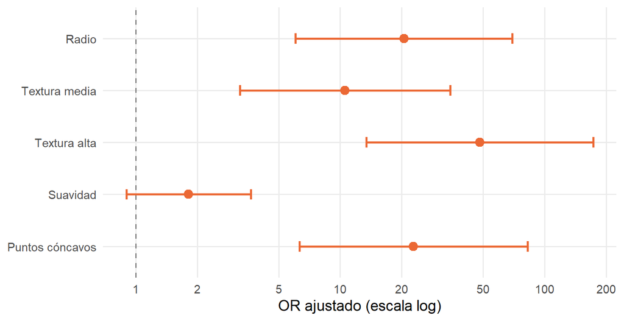

Figura 4. OR ajustados del modelo final (IC 95 %, escala logarítmica).

```r
data.frame(var = coef_lab[names(coef(m_final))[-1]], OR = or_final[-1], LI = ic[-1, 1], LS = ic[-1, 2]) %>%
  mutate(var = factor(var, levels = rev(var))) %>%
  ggplot(aes(OR, var)) +
  geom_vline(xintercept = 1, linetype = "dashed", color = "grey50") +
  geom_errorbarh(aes(xmin = LI, xmax = LS), height = 0.2, color = col_dx["Maligno"], linewidth = 0.8) +
  geom_point(size = 3, color = col_dx["Maligno"]) +
  scale_x_log10(breaks = c(0.5, 1, 2, 5, 10, 20, 50, 100, 200)) +
  labs(x = "OR ajustado (escala log)", y = NULL)
```

**Interpretación (manteniendo constantes las demás variables):**

- **Radio:** por cada aumento de 1 DE (3,52 unidades), los odds de malignidad se multiplican por 20,5 (IC 95 %: 6,0–69,6).
- **Textura:** respecto de las masas con textura baja, los odds de malignidad son 10,6 veces mayores con textura media y 48,2 veces mayores con textura alta.
- **Puntos cóncavos:** por cada aumento de 1 DE (0,039 unidades), los odds de malignidad se multiplican por 22,8 (IC 95 %: 6,3–82,6).
- **Suavidad:** OR = 1,81 por 1 DE, no significativo (p = 0,096); se conserva por su rol como confusora.

Los intervalos de confianza son amplios porque las variables discriminan casi perfectamente y hay pocas masas con valores intermedios; la dirección y la significación de los efectos son, sin embargo, claras.

### 3.3.7 Verificación de supuestos del modelo final

```r
data.frame(Variable = etiq_p[rownames(vif(m_final))],
           `GVIF^(1/(2·gl))` = fn(vif(m_final)[, 3], 2), check.names = FALSE) %>% kable(row.names = FALSE)
```

| Variable | GVIF^(1/(2·gl)) |
| --- | --- |
| Radio | 1,37 |
| Textura (terciles) | 1,10 |
| Suavidad | 1,64 |
| Puntos cóncavos | 1,45 |

```r
cook <- cooks.distance(m_final)
c(n_cook_mayor_4n = sum(cook > 4 / nrow(datos)), cook_max = round(max(cook), 3))
```

```
## n_cook_mayor_4n        cook_max
##          38.000           0.119
```

```r
# Sensibilidad: reajuste (a) sin las 10 observaciones de mayor distancia de Cook
#               y (b) sin todas las que superan 4/n
top10 <- order(cook, decreasing = TRUE)[1:10]
m_sin10   <- update(m_final, data = datos_z[-top10, ])
m_sin_inf <- update(m_final, data = datos_z[cook <= 4 / nrow(datos), ])
signif(cbind(OR_completo = exp(coef(m_final)), OR_sin_top10 = exp(coef(m_sin10)),
             OR_sin_mayores_4n = exp(coef(m_sin_inf))), 3)
```

```
##                     OR_completo OR_sin_top10 OR_sin_mayores_4n
## (Intercept)              0.0583       0.0118         1.03e-146
## radius_mean             20.5000      62.8000         1.56e+150
## textura_catMedia        10.6000      42.3000         4.07e+106
## textura_catAlta         48.2000     359.0000         3.24e+197
## smoothness_mean          1.8100       2.6600          8.41e+57
## concave.points_mean     22.8000      58.8000         7.00e+154
```

```r
# Clasificación del modelo sin influyentes: ¿separación completa?
table(Predicho = fitted(m_sin_inf) > 0.5, Observado = m_sin_inf$y)
```

```
##         Observado
## Predicho   0   1
##    FALSE 340   0
##    TRUE    0 191
```

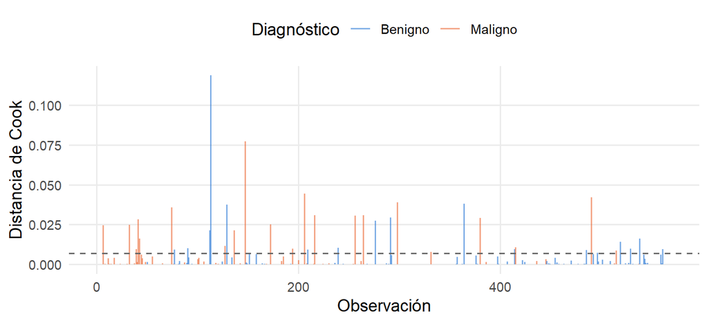

Figura 5. Distancia de Cook de cada observación.

```r
data.frame(obs = seq_along(cook), cook = cook, dx = datos$diagnostico) %>%
  ggplot(aes(obs, cook, color = dx)) +
  geom_segment(aes(xend = obs, yend = 0), alpha = 0.6) +
  geom_hline(yintercept = 4 / nrow(datos), linetype = "dashed", color = "grey40") +
  scale_color_manual(values = col_dx) +
  labs(x = "Observación", y = "Distancia de Cook", color = "Diagnóstico")
```

- **Independencia:** cada fila corresponde a una masa distinta.
- **Multicolinealidad:** todos los GVIF corregidos son menores que 2.
- **Linealidad en el logit:** se cumple para el radio, la suavidad y los puntos cóncavos (Box-Tidwell); la textura se resolvió con terciles.
- **Observaciones influyentes:** hay **observaciones potencialmente influyentes y el modelo es sensible a ellas**. 38 observaciones superan el umbral 4/n; que el máximo (0,119) sea menor que 1 no alcanza para descartar influencia, porque el análisis de sensibilidad muestra que las estimaciones cambian mucho: al excluir solo las 10 de mayor distancia de Cook, el OR del radio pasa de 20,5 a 62,8 y el de la textura alta de 48,2 a 358,5; al excluir las 38, el resto de las masas queda **perfectamente separado** (el modelo clasifica todo sin error) y los OR tienden a infinito, es decir, el modelo deja de ser estimable. Esas observaciones no son errores de carga, sino los casos “difíciles” (benignas con valores altos o malignas con valores bajos) que informan sobre la zona de superposición entre grupos; excluirlas sería descartar justamente la información que permite estimar el modelo, por lo que **se conservan**. La consecuencia es que la **dirección** de las asociaciones es estable (todos los OR siguen siendo mayores que 1), pero su **magnitud** depende de unas pocas decenas de casos y debe interpretarse con cautela.

### 3.3.8 Bondad de ajuste y capacidad discriminativa

```r
# Test de Hosmer-Lemeshow, implementación propia
hosmer_lemeshow <- function(y, p, g = 10) {
  grupos <- cut(p, breaks = unique(quantile(p, probs = seq(0, 1, 1 / g))), include.lowest = TRUE)
  obs <- tapply(y, grupos, sum); esp <- tapply(p, grupos, sum); n <- tapply(y, grupos, length)
  chi2 <- sum((obs - esp)^2 / (esp * (1 - esp / n)))
  gl <- length(n) - 2
  list(chi2 = chi2, gl = gl, p = 1 - pchisq(chi2, gl), n_grupos = length(n),
       tabla = data.frame(n = as.vector(n), Observados = as.vector(obs),
                          Esperados = round(as.vector(esp), 2)))
}
p_hat <- fitted(m_final)
hl <- hosmer_lemeshow(datos$diagnosis_num, p_hat)
hl[c("chi2", "gl", "p", "n_grupos")]
```

```
## $chi2
## [1] 6.279964
##
## $gl
## [1] 8
##
## $p
## [1] 0.6159034
##
## $n_grupos
## [1] 10
```

```r
# Grupos realmente formados: malignas observadas y esperadas en cada decil de riesgo
kable(cbind(Grupo = seq_len(hl$n_grupos), hl$tabla), row.names = FALSE,
      caption = "Hosmer-Lemeshow: malignas observadas y esperadas por grupo de riesgo predicho")
```

Hosmer-Lemeshow: malignas observadas y esperadas por grupo de riesgo predicho

| Grupo | n | Observados | Esperados |
| --- | --- | --- | --- |
| 1 | 57 | 0 | 0.01 |
| 2 | 57 | 0 | 0.06 |
| 3 | 57 | 0 | 0.18 |
| 4 | 57 | 0 | 0.52 |
| 5 | 57 | 2 | 1.79 |
| 6 | 56 | 11 | 7.85 |
| 7 | 57 | 28 | 32.84 |
| 8 | 57 | 57 | 54.83 |
| 9 | 57 | 57 | 56.92 |
| 10 | 57 | 57 | 57.00 |

```r
# Verificación contra una implementación estándar
if (requireNamespace("ResourceSelection", quietly = TRUE)) {
  hl_std <- ResourceSelection::hoslem.test(datos$diagnosis_num, p_hat, g = 10)
  print(c(chi2_propio = hl$chi2, chi2_hoslem.test = unname(hl_std$statistic),
          p_propio = hl$p, p_hoslem.test = hl_std$p.value))
}
```

```
##      chi2_propio chi2_hoslem.test         p_propio    p_hoslem.test
##        6.2799637        6.2799637        0.6159034        0.6159034
```

El test de Hosmer-Lemeshow **no detecta falta de ajuste** (χ² = 6,28, gl = 8, p = 0,616). Se formaron efectivamente 10 grupos y la implementación propia coincide con `ResourceSelection::hoslem.test`. Este resultado **no demuestra que la calibración sea perfecta**: un p alto solo indica que no hay evidencia suficiente contra el ajuste, y el test tiene poca potencia y depende de cómo se armen los grupos. Además, como el modelo discrimina casi perfectamente, en 4 de los 10 grupos se espera menos de una masa maligna, por lo que la aproximación χ² es débil y en la práctica el test se apoya en los pocos grupos de riesgo intermedio. Por eso se complementa con la curva de calibración (Figura 6).

```r
pred_cat <- factor(ifelse(p_hat >= 0.5, "Maligno", "Benigno"), levels = c("Benigno", "Maligno"))
mc <- table(Predicho = pred_cat, Observado = datos$diagnostico)
mc
```

```
##          Observado
## Predicho  Benigno Maligno
##   Benigno     343      18
##   Maligno      14     194
```

```r
VP <- mc["Maligno", "Maligno"]; VN <- mc["Benigno", "Benigno"]
FP <- mc["Maligno", "Benigno"]; FN <- mc["Benigno", "Maligno"]
metricas <- c(Sensibilidad = VP / (VP + FN), Especificidad = VN / (VN + FP),
              VPP = VP / (VP + FP), VPN = VN / (VN + FN),
              Exactitud = (VP + VN) / sum(mc))
data.frame(`Métrica` = names(metricas), Valor = paste0(fn(100 * metricas, 1), " %")) %>% kable(row.names = FALSE)
```

| Métrica | Valor |
| --- | --- |
| Sensibilidad | 91,5 % |
| Especificidad | 96,1 % |
| VPP | 93,3 % |
| VPN | 95,0 % |
| Exactitud | 94,4 % |

```r
roc_final <- roc(datos$diagnosis_num, p_hat, quiet = TRUE)
auc_ic <- ci.auc(roc_final)

# Selección automática de variables, para poder repetirla dentro de cada partición.
# Imita el proceso manual: (1) descartar de a una la variable de mayor VIF hasta que todos
# sean <= 5; (2) eliminación hacia atrás por LRT (p > 0,05). La textura entra como continua.
seleccionar <- function(dtr) {
  cols <- vars
  repeat {
    if (length(cols) < 2) break
    v <- vif(glm(reformulate(cols, "diagnosis_num"), data = dtr, family = binomial))
    if (max(v) > 5) cols <- setdiff(cols, names(which.max(v))) else break
  }
  repeat {
    if (length(cols) < 2) break
    d1 <- drop1(glm(reformulate(cols, "diagnosis_num"), data = dtr, family = binomial), test = "LRT")
    pv <- setNames(d1$`Pr(>Chi)`[-1], rownames(d1)[-1])
    if (max(pv) > 0.05) cols <- setdiff(cols, names(which.max(pv))) else break
  }
  cols
}

# Validación cruzada de 10 particiones, repetida 10 veces
#  (a) modelo fijo: se reajusta el modelo final ya elegido
#  (b) proceso completo: estandarización y selección de variables repetidas en cada partición
y_obs <- datos$diagnosis_num
cv <- lapply(1:10, function(r) {
  folds <- sample(rep(1:10, length.out = nrow(datos)))
  p_fijo <- p_sel <- numeric(nrow(datos)); elegidas <- character(0)
  for (k in 1:10) {
    tr <- folds != k
    # (a)
    m_k <- update(m_final, data = datos_z[tr, ])
    p_fijo[!tr] <- predict(m_k, newdata = datos_z[!tr, ], type = "response")
    # (b) todo se calcula solo con los datos de entrenamiento
    mu <- sapply(datos[tr, vars], mean); de <- sapply(datos[tr, vars], sd)
    dtr <- datos[tr, c("diagnosis_num", vars)]; dte <- datos[!tr, c("diagnosis_num", vars)]
    dtr[vars] <- scale(dtr[vars], mu, de); dte[vars] <- scale(dte[vars], mu, de)
    cols <- seleccionar(dtr)
    m_s <- glm(reformulate(cols, "diagnosis_num"), data = dtr, family = binomial)
    p_sel[!tr] <- predict(m_s, newdata = dte, type = "response")
    elegidas <- c(elegidas, cols)
  }
  list(auc_fijo = as.numeric(auc(y_obs, p_fijo, quiet = TRUE)),
       auc_sel  = as.numeric(auc(y_obs, p_sel, quiet = TRUE)),
       sens = mean(p_fijo[y_obs == 1] >= 0.5), esp = mean(p_fijo[y_obs == 0] < 0.5),
       elegidas = elegidas)
})
auc_cv     <- sapply(cv, `[[`, "auc_fijo")
auc_cv_sel <- sapply(cv, `[[`, "auc_sel")
sens_cv    <- mean(sapply(cv, `[[`, "sens")); esp_cv <- mean(sapply(cv, `[[`, "esp"))

c(AUC_aparente = as.numeric(auc(roc_final)), AUC_CV_modelo_fijo = mean(auc_cv),
  AUC_CV_con_seleccion = mean(auc_cv_sel))
```

```
##         AUC_aparente   AUC_CV_modelo_fijo AUC_CV_con_seleccion
##            0.9867211            0.9842833            0.9834232
```

```r
c(Sensibilidad_CV = sens_cv, Especificidad_CV = esp_cv)
```

```
##  Sensibilidad_CV Especificidad_CV
##        0.9061321        0.9579832
```

```r
# ¿Qué variables elige el proceso automático? (% de los 100 ajustes en que queda cada una)
frec_sel <- sort(table(unlist(lapply(cv, `[[`, "elegidas"))), decreasing = TRUE)
data.frame(Variable = etiq[names(frec_sel)], `% de particiones` = as.vector(frec_sel),
           check.names = FALSE) %>% kable(row.names = FALSE)
```

| Variable | % de particiones |
| --- | --- |
| Área | 100 |
| Textura | 100 |
| Suavidad | 96 |
| Concavidad | 77 |
| Puntos cóncavos | 25 |
| Simetría | 5 |
| Compacidad | 3 |

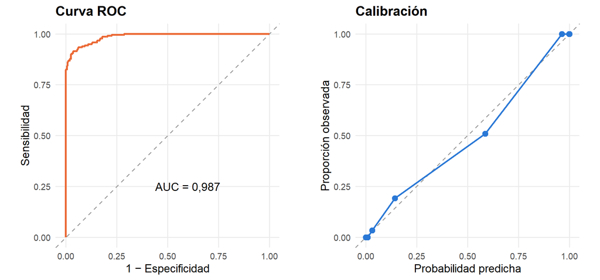

Figura 6. Curva ROC (izquierda) y calibración por deciles de riesgo predicho (derecha).

```r
g_roc <- data.frame(fpr = 1 - roc_final$specificities, tpr = roc_final$sensitivities) %>%
  arrange(fpr, tpr) %>%
  ggplot(aes(fpr, tpr)) +
  geom_abline(linetype = "dashed", color = "grey60") +
  geom_path(color = col_dx["Maligno"], linewidth = 1) +
  annotate("text", x = 0.6, y = 0.25, label = paste0("AUC = ", fn(auc(roc_final), 3))) +
  coord_equal() +
  labs(x = "1 − Especificidad", y = "Sensibilidad", title = "Curva ROC")

g_cal <- data.frame(y = datos$diagnosis_num, p = p_hat) %>%
  mutate(decil = ntile(p, 10)) %>%
  group_by(decil) %>% summarise(pred = mean(p), obs = mean(y)) %>%
  ggplot(aes(pred, obs)) +
  geom_abline(linetype = "dashed", color = "grey60") +
  geom_line(color = col_dx["Benigno"], linewidth = 0.8) +
  geom_point(color = col_dx["Benigno"], size = 2.5) +
  coord_equal(xlim = c(0, 1), ylim = c(0, 1)) +
  labs(x = "Probabilidad predicha", y = "Proporción observada", title = "Calibración")

grid.arrange(g_roc, g_cal, ncol = 2)
```

El modelo tiene una **capacidad discriminativa excelente**: AUC = 0,987 (IC 95 %: 0,980–0,993). Con un punto de corte de 0,5, la sensibilidad aparente es de 91,5 % y la especificidad, de 96,1 % (90,6 % y 95,8 % en validación cruzada).

# 4 Conclusión

## 4.1 Resumen de resultados

1. **Diseño:** estudio observacional, transversal, analítico y retrospectivo de exactitud diagnóstica, con 569 masas mamarias evaluadas por PAF (37,3 % malignas).
2. **Univariado:** 9 de las 10 características nucleares difieren entre masas benignas y malignas (Mann-Whitney con corrección de Holm). Los efectos más grandes corresponden al tamaño y a la concavidad del contorno.
3. **Multivariado:** el modelo saturado es inutilizable por multicolinealidad severa (VIF > 100). Tras reducirlo, el modelo final incluye cuatro características: **radio**, **textura** (en terciles, por no linealidad) y **puntos cóncavos**, asociadas significativamente con la malignidad, y **suavidad**, no significativa pero conservada por su señal de confusión. El modelo es sensible a un grupo de observaciones potencialmente influyentes: la dirección de las asociaciones es estable, pero la magnitud de los OR no.
4. **Confusión y modificación de efecto:** según el cambio en los coeficientes (criterio heurístico del 10 %), el radio y los puntos cóncavos se confunden mutuamente y la suavidad muestra señal de confusión sobre ambos, pero no sobre la textura. No hay evidencia de modificación de efecto.
5. **Desempeño:** discriminación excelente (AUC = 0,987; por validación cruzada, 0,984 con el modelo fijo y 0,983 repitiendo la selección de variables en cada partición), sin evidencia de falta de ajuste (Hosmer-Lemeshow p = 0,616, lo que no demuestra calibración perfecta), sensibilidad de 91,5 % y especificidad de 96,1 %.

## 4.2 Interpretación

Los núcleos de las masas malignas son **más grandes, más heterogéneos en su tinción (textura) y de contorno más irregular (más puntos cóncavos)** que los de las masas benignas. Cada una de estas características se asocia con la malignidad de forma independiente de las demás. Esto coincide con los criterios citológicos clásicos de malignidad (pleomorfismo, aumento del tamaño nuclear, irregularidad de la membrana nuclear). Con solo cuatro medidas obtenidas automáticamente de la imagen de una PAF, el modelo clasifica correctamente el 94,4 % de las masas, lo que muestra el potencial del análisis de imágenes para objetivar la citología.

Los OR deben interpretarse como **asociaciones**, no como efectos causales: las características nucleares son manifestaciones del tumor, no sus causas. La “confusión” entre radio y puntos cóncavos refleja que ambas expresan, en parte, el mismo proceso de transformación maligna.

## 4.3 Limitaciones

- **Validez externa:** se trata de un único centro de referencia en EE. UU. a comienzos de los 90, con posible sesgo de espectro. El rendimiento podría ser menor en otras poblaciones o con otros equipos de digitalización.
- **Estándar de referencia:** la base no detalla cómo se confirmó cada diagnóstico benigno (posible sesgo de verificación).
- **Validación:** la validación es solo interna y la selección de variables se hizo con todos los datos; la variante con selección dentro de cada partición es una aproximación y no reemplaza a una validación cruzada anidada completa ni a una validación externa, necesaria antes de cualquier uso clínico.
- **Estabilidad de las estimaciones:** la magnitud de los OR depende de unas pocas decenas de observaciones de la zona de superposición entre grupos (cuasi-separación), por lo que los valores puntuales deben tomarse con cautela.
- **Decisiones analíticas:** la elección de Mann-Whitney a partir de Shapiro-Wilk y el umbral del 10 % para confusión son criterios operativos, no reglas universales.
- **Punto de corte:** el corte de 0,5 no es necesariamente el óptimo clínico. En cáncer conviene priorizar la sensibilidad, por lo que podría elegirse un corte menor a costa de más falsos positivos.

## 4.4 Respuestas a la matriz de evaluación

| Pregunta | Dónde se responde |
| --- | --- |
| 1. Diseño y PICO | Secciones 1.4 y 2.1 |
| 2. Sesgos | Sección 2.5 |
| 3. Variables, distribución y test | Secciones 2.4, 3.1 y 2.7 |
| 4. Análisis univariado | Sección 3.2 |
| 5. Modelo multivariado saturado, supuestos y dummies | Secciones 3.3.1 a 3.3.3, 3.3.6 y 3.3.7 |
| 6. Confusoras y modificadoras de efecto | Secciones 3.3.4 y 3.3.5 |
| 7. Resumen, conclusión y gráficos | Sección 4 y Figuras 1 a 6 |

# 5 Referencias bibliográficas

1. Kim J, Harper A, McCormack V, Sung H, Houssami N, Morgan E, et al. Global patterns and trends in breast cancer incidence and mortality across 185 countries. *Nat Med*. 2025. doi:10.1038/s41591-025-03502-3.
2. Street WN, Wolberg WH, Mangasarian OL. Nuclear feature extraction for breast tumor diagnosis. *Proc SPIE*. 1993;1905:861–870.
3. Wolberg WH, Street WN, Mangasarian OL. Machine learning techniques to diagnose breast cancer from image-processed nuclear features of fine needle aspirates. *Cancer Lett*. 1994;77(2–3):163–171.
4. Wolberg WH, Mangasarian OL, Street N, Street WN. Breast Cancer Wisconsin (Diagnostic) [Dataset]. UCI Machine Learning Repository; 1995. doi:10.24432/C5DW2B.
5. UCI Machine Learning. Breast Cancer Wisconsin (Diagnostic) Data Set. Kaggle. https://www.kaggle.com/datasets/uciml/breast-cancer-wisconsin-data.
6. Hosmer DW, Lemeshow S, Sturdivant RX. *Applied Logistic Regression*. 3.ª ed. Hoboken: Wiley; 2013.
7. Peduzzi P, Concato J, Kemper E, Holford TR, Feinstein AR. A simulation study of the number of events per variable in logistic regression analysis. *J Clin Epidemiol*. 1996;49(12):1373–1379.
8. Box GEP, Tidwell PW. Transformation of the independent variables. *Technometrics*. 1962;4(4):531–550.
9. Cohen J. *Statistical Power Analysis for the Behavioral Sciences*. 2.ª ed. Hillsdale: Lawrence Erlbaum; 1988.
10. Ransohoff DF, Feinstein AR. Problems of spectrum and bias in evaluating the efficacy of diagnostic tests. *N Engl J Med*. 1978;299(17):926–930.
11. Bossuyt PM, Reitsma JB, Bruns DE, Gatsonis CA, Glasziou PP, Irwig L, et al. STARD 2015: an updated list of essential items for reporting diagnostic accuracy studies. *BMJ*. 2015;351:h5527.
12. von Elm E, Altman DG, Egger M, Pocock SJ, Gøtzsche PC, Vandenbroucke JP. The Strengthening the Reporting of Observational Studies in Epidemiology (STROBE) statement. *Lancet*. 2007;370(9596):1453–1457.
13. R Core Team. *R: A Language and Environment for Statistical Computing*. Viena: R Foundation for Statistical Computing. https://www.R-project.org/.